## Activity pattern before and after filling the missing values

Now we like to plot a histogram of daily total number of steps before and after filling the missing values. We have the group daily sum table with missing values(aggSumByDay). WE need to generate the same for the new.data table:

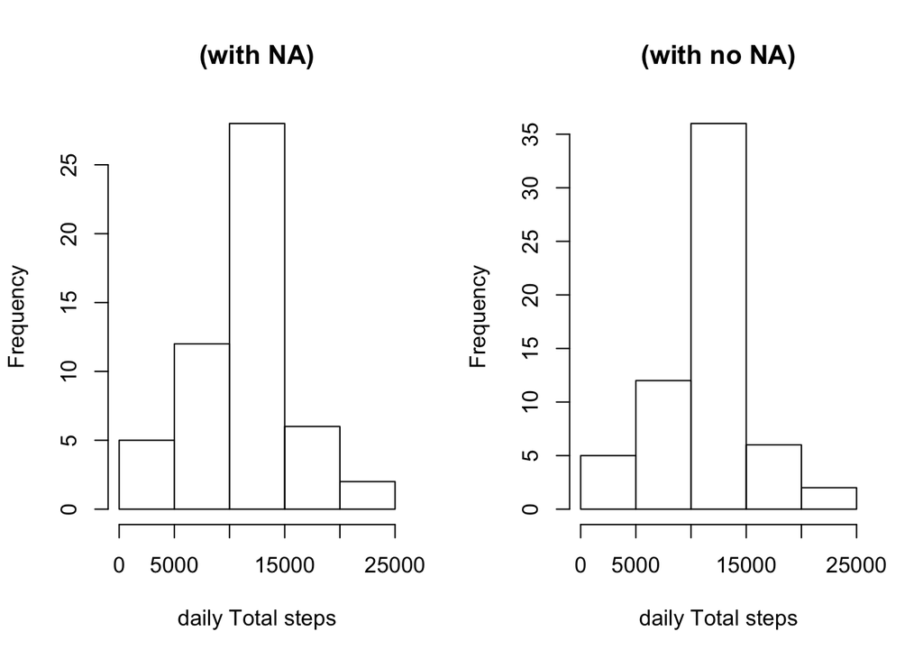

```r
aggSumByDay2 <- aggregate(steps ~ date, new.data, sum)
names(aggSumByDay2)<- c("day", "totalsteps")
par(mfrow = c(1, 2))
hist(aggSumByDay$totalsteps, main = "(with NA)", xlab = "daily Total steps")

hist(aggSumByDay2$totalsteps, main = "(with no NA)", xlab = "daily Total steps")
```

Histograms show that with or wothout missing values, the activity pattern shows similar pattern. The replaced value for missing data could be more sophisticated, but as it was mentioned in assignment question I took just a very simple way. Mean for total daily steps having missing values is:

```r
mean(aggSumByDay$totalsteps)
```

```
## [1] 10766.19
```

And the median total daily steps having missing values is:

```r
median(aggSumByDay$totalsteps)
```

```
## [1] 10765
```

Mean for total daily steps after replacing all missing values is:

```r
mean(aggSumByDay2$totalsteps)
```

```
## [1] 10766.19
```

And the median total daily steps after replacing missing values is:

```r
median(aggSumByDay2$totalsteps)
```

```
## [1] 10766.19
```

## Are there differences in activity patterns between weekdays and weekends?

```r
new.data$weekdays <- factor(format(new.data$date, "%A"))
levels(new.data$weekdays)  # making sure all different factors are week days
```

```
## [1] "Friday"    "Monday"    "Saturday"  "Sunday"    "Thursday"  "Tuesday"
## [7] "Wednesday"
```

Now because we are investigating about the difference between weekend days and weekdays we can change the weekdays column to two factors, (weekday, weekend)

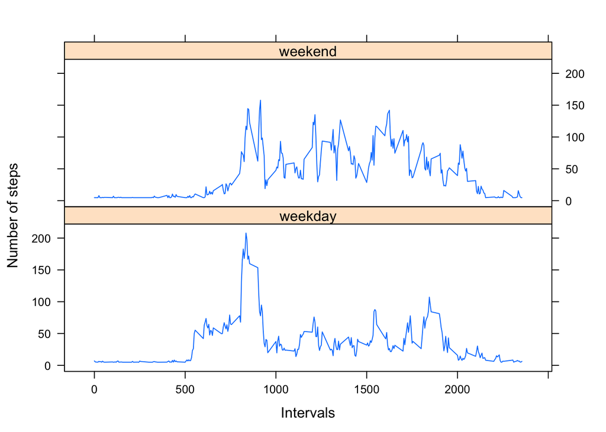

```r
days<- list(weekday = c("Monday", "Tuesday", "Wednesday",
    "Thursday", "Friday"), weekend = c("Saturday", "Sunday"))
levels(new.data$weekdays)<- days
new.data.mean.by.interval <- aggregate(new.data$steps, by = list(new.data$weekdays,
    new.data$interval),  mean, na.rm = TRUE, na.action = NULL)

names(new.data.mean.by.interval)<- c("weekdays","intervals","mean.steps")

library(lattice)
xyplot(new.data.mean.by.interval$mean.steps ~ new.data.mean.by.interval$intervals |
    new.data.mean.by.interval$weekdays, layout = c(1, 2), type = "l", xlab = "Intervals",
    ylab = "Number of steps")
```

Average number of steps on weekends seems to be higher. This person is more active on weekends

```r
new.data.mean.by.weekday<- aggregate(steps ~ weekdays, new.data,mean)
new.data.mean.by.weekday
```

```
##   weekdays    steps
## 1  weekday 35.61058
## 2  weekend 42.36640
```